# Администрирование сетевых подсистем

Лабораторная работа №5.

Тойчубекова Асель Нурлановна

kulyabov-ds@rudn.ru

Российский университет дружбы народов

2025-10-04

# Информация

## Докладчик

- Тойчубекова Асель Нурлановна
- Студент 3 курса
- факультет физико-математических и естественных наук
- Российский университет дружбы народов им. П. Лумумбы
- 1032235033@rudn.ru

## Цель работы

Приобретение практических навыков по расширенному конфигурированию HTTP-сервера Apache в части безопасности и возможности использования PHP.

## Теоретическое введение

HTTPS (HyperText Transfer Protocol Secure) — это защищённое расширение протокола HTTP, обеспечивающее безопасную передачу данных между клиентом и сервером с использованием шифрования.

Безопасность HTTPS достигается за счёт применения криптографических протоколов SSL или TLS, которые обеспечивают:

- Конфиденциальность — данные шифруются и не могут быть перехвачены;
- Целостность — данные не могут быть изменены при передаче;
- Аутентификацию — подтверждение подлинности сервера и клиента.

## Теоретическое введение

При работе HTTPS используется комбинация двух видов шифрования:

- Асимметричное шифрование — применяется для обмена ключами, использует пару ключей (открытый и закрытый);
- Симметричное шифрование — используется для быстрой передачи данных с помощью одного общего ключа.

## Теоретическое введение

Сертификат безопасности содержит открытый ключ и информацию о владельце сайта. Он подтверждается сертификационным центром (CA), который гарантирует подлинность владельца ресурса.

## Задание

1. Сгенерирую криптографический ключ и самоподписанный сертификат безопасности для возможности перехода веб-сервера от работы через протокол HTTP к работе через протокол HTTPS.
2. Настрою веб-сервер для работы с PHP.
3. Напишу скрипт для Vagrant, фиксирующий действия по расширенной настройке HTTP-сервера во внутреннем окружении виртуальной машины server.

# Выполнение лабораторной работы

## Выполнение лабораторной работы

Для начала лабораторной рабоаты №5 включим вм server и войдем под нашим пользователем, откроем терминал и войдем в режим суперпользователя. В каталоге /etc/ssl создадим каталог private.

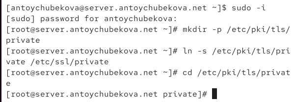

Создание каталога private

## Выполнение лабораторной работы

Сгенерируем ключ и сертификат, используя следующую команду: openssl req -x509 -nodes -newkey rsa:2048 -keyout www.antoychubekova.net.key -out www.antoychubekova.net.crt. При запросе заполним сертифакат, заполняем сертификат как указано в лабораторной работе.

## Выполнение лабораторной работы

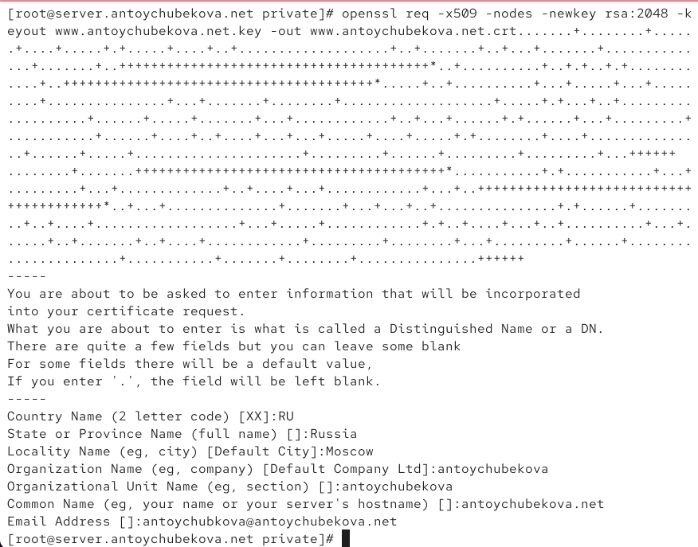

Генерация ключа и сертификата

## Выполнение лабораторной работы

Перенесем www.antoychubekova.net.crt в каталог /etc/pki/tls/certs.

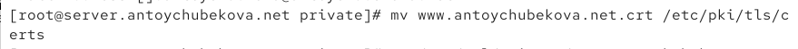

Перемещение сертификата

## Выполнение лабораторной работы

Затем скопируем сертификат в каталог /etc/ssl/certs.

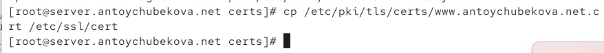

Копирование сертификата

## Выполнение лабораторной работы

Для перехода веб-сервера www.user.net на функционирование через протокол HTTPS требуется изменить его конфигурационный файл. Перейдем в каталог с конфигурационными файлами. И откроем на редактирование конфигурационный файл www.antoychubekova.net.conf. Изменяем содержимое на следующее содержание:

- <VirtualHost *:80> — Открывает блок конфигурации для виртуального хоста, работающего на порту 80 (HTTP).* означает, что сервер принимает соединения на всех IP-адресах.
- ServerAdmin webmaster@antoychubekova.net — Почта администратора сайта. На эту почту Apache будет отправлять уведомления об ошибках (если включено).
- DocumentRoot /var/www/html/www.antoychubekova.net — Каталог, где находятся файлы сайта (главная страница, изображения, скрипты и т.д.).

## Выполнение лабораторной работы

- ServerName www.antoychubekova.net — Основное доменное имя, с которым связан этот виртуальный хост.
- ServerAlias www.antoychubekova.net — Дополнительное имя домена (алиас). В данном случае оно дублирует ServerName, что не обязательно, но не мешает.
- ErrorLog logs/www.antoychubekova.net-error_log — Файл журнала ошибок (куда Apache записывает все ошибки, произошедшие при обслуживании этого сайта).
- CustomLog logs/www.antoychubekova.net-access_log common — Файл журнала обращений (все запросы пользователей к сайту). common — стандартный формат логирования.

## Выполнение лабораторной работы

- RewriteEngine on — Включает модуль mod_rewrite, который позволяет использовать правила перенаправления (редиректы).
- RewriteRule ^(.*)$ https://%{HTTP_HOST}$1 [R=301,L] — Правило перенаправления всех HTTP-запросов на HTTPS.

Расшифровка:

- ^(.*)$ — соответствует любому пути запроса;
- https://%{HTTP_HOST}$1 — перенаправляет на тот же хост, но с HTTPS;
- [R=301,L] — делает постоянное перенаправление (код 301) и указывает, что это последнее правило.

## Выполнение лабораторной работы

- ServerAdmin webmaster@antoychubekova.net — Почта администратора (та же, что и выше).
- DocumentRoot /var/www/html/www.antoychubekova.net — Корневая директория сайта (та же, что и для HTTP).
- ServerName www.antoychubekova.net
- ServerAlias www.antoychubekova.net — Основное и дополнительное имя сайта (дублируют HTTP-настройки).

## Выполнение лабораторной работы

- ErrorLog logs/www.antoychubekova.net-error_log
- CustomLog logs/www.antoychubekova.net-access_log common — Файлы логов (ошибки и обращения по HTTPS).
- SSLCertificateFile /etc/ssl/certs/www.antoychubekova.net.crt — Путь к файлу SSL-сертификата (публичная часть).

## Выполнение лабораторной работы

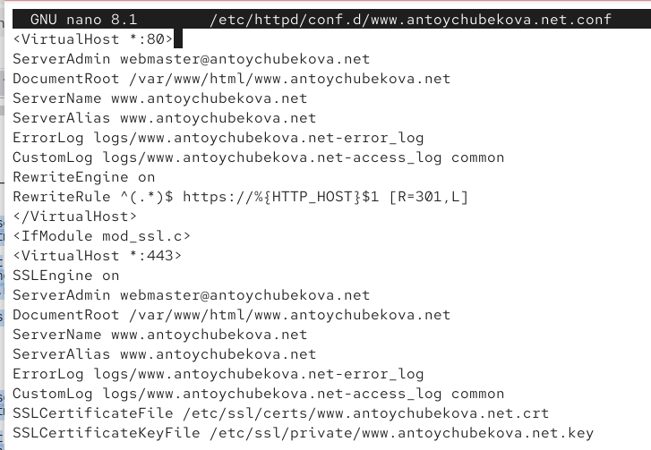

Редактирование конфигурационного файла

## Выполнение лабораторной работы

Внесем изменения в настройки межсетевого экрана на сервере, разрешив работу с https.

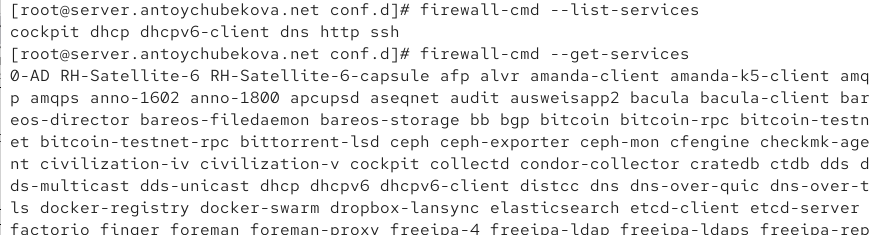

Изменения межсетевого экрана на сервере

## Выполнение лабораторной работы

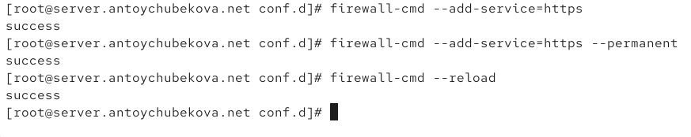

Изменения межсетевого экрана на сервере

## Выполнение лабораторной работы

Перезапустим веб-сервер.

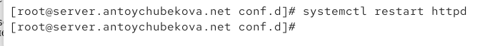

Перезапуск веб-сервера

## Выполнение лабораторной работы

На виртуальной машине client в строке браузера введем название веб-сервера www.antoychubekova.net и видим, что произошла автоматическое переключение на работу по протоколу HTTPS. На открывшейся странице с сообщением о незащищённости соединения нажмем кнопку «Дополнительно», затем добавим адрес нашего сервера в постоянные исключения.

## Выполнение лабораторной работы

[figure not shown]

Проверка работы https

## Выполнение лабораторной работы

Затем просмотрим содержание сертификата. Мы видим, что в сертификате указаны те данные, которые мы указывали при его создании.

[figure not shown]

Просмотр сертификата

## Выполнение лабораторной работы

Установим пакеты для работы с PHP.

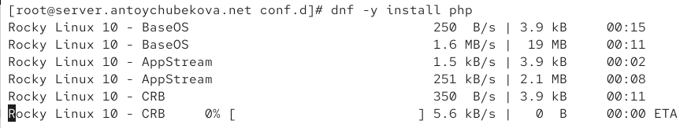

Установка php

## Выполнение лабораторной работы

В каталоге /var/www/html/www.antoychubekova.net заменим файл index.html на index.php следующего содержания: -

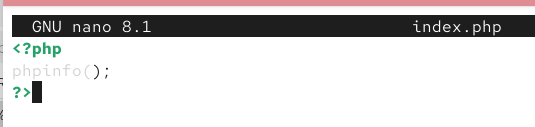

Создания php файла

## Выполнение лабораторной работы

Скорректируем права доступа в каталог с веб-контентом. И восстановим контекст безопасности в SELinux. Затем перезапустим http-сервер.

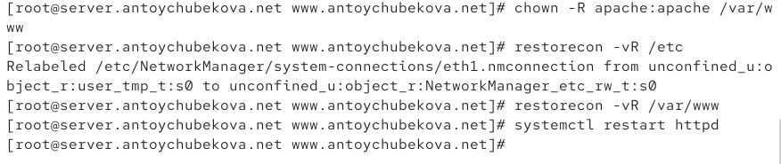

Перезапуск http-сервера

## Выполнение лабораторной работы

На виртуальной машине client в строке браузера введем название веб-сервера www.antoychubekova.net и видим, что выводится страница с информацией об используемой на веб-сервере версии PHP.

[figure not shown]

Проверка работы php

## Выполнение лабораторной работы

На виртуальной машине server перейдем в каталог для внесения изменений в настройки внутреннего окружения /vagrant/provision/server/http и в соответствующие каталоги скопируем конфигурационные файлы.

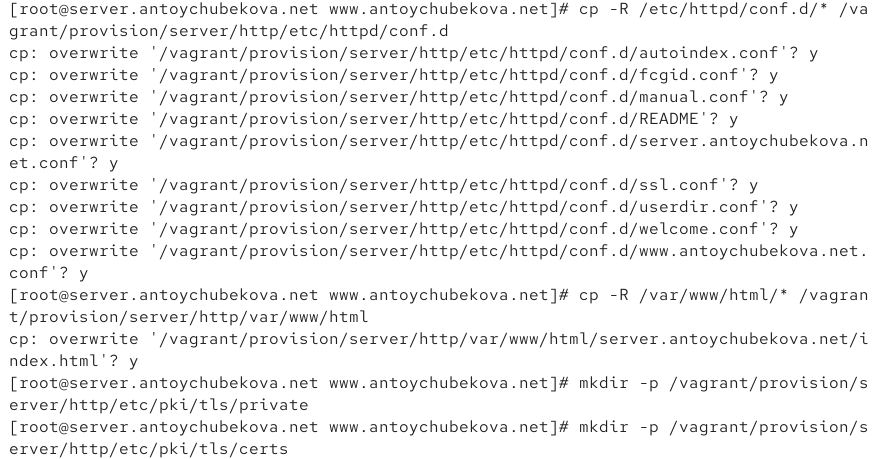

Копирование конфигурационных файлов

## Выполнение лабораторной работы

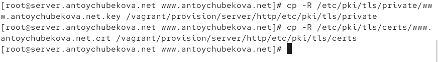

Копирование конфигурационных файлов

## Выполнение лабораторной работы

В имеющийся скрипт /vagrant/provision/server/http.sh внесем изменения, добавив установку PHP и настройку межсетевого экрана, разрешающую работать с https.

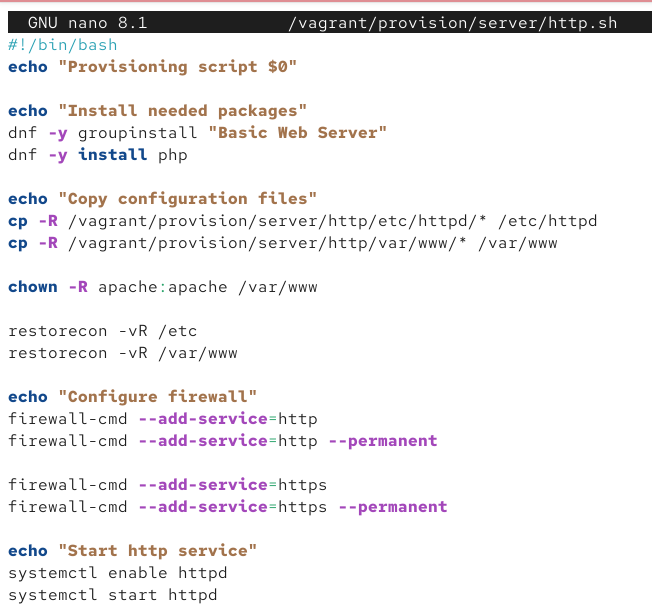

Редактирование исполняемого файла

## Выводы

В ходе выполенения лабораторрной работы №5 я приобрела практические навыки по расширенному конфигурированию HTTP-сервера Apache в части безопасности и возможности использования PHP.

## Список литературы.

1. Barr D. Common DNS Operational and Configuration Errors: RFC / RFC Editor. —02/1996. — DOI: 10.17487/rfc1912.
2. Security-Enhanced Linux. Linux с улучшенной безопасностью: руководство пользователя / M. McAllister, S. Radvan, D. Walsh, D. Grift, E. Paris, J. Morris. — URL: https://docs-old.fedoraproject.org/ru-RU/Fedora/13/html/Security-Enhanced_Linux/index.html (дата обр.13.09.2021).
3. Systemd. — 2015. — URL: https:/ /wiki .archlinux .org /index .php /Systemd (visited on 09/13/2021).
4. Костромин В. А. Утилита lsof — инструмент администратора. — URL: http : / / rus linux.net/kos.php?name=/papers/lsof/lsof.html (дата обр. 13.09.2021).